# Risk Factor Analysis

## Outcome Variable

**Outcome Variable:** wast_rec90d

## Predictor Variables

**Intervention Variable:** nchldlt5

**Adjustment Set:**

- arm
- W_mage
- meducyrs
- feducyrs
- hhwealth_quart
- hfoodsec
- W_mhtcm
- W_nrooms
- W_parity
- impfloor
- impsan
- safeh20
- delta_W_mage
- delta_meducyrs
- delta_feducyrs
- delta_hhwealth_quart
- delta_hfoodsec
- delta_W_mhtcm
- delta_W_nrooms
- delta_W_parity
- delta_impfloor
- delta_impsan
- delta_safeh20

## Stratifying Variables

The analysis was stratified on these variable(s):

- agecat
- studyid
- country

## Data Summary

| agecat | studyid | country | nchldlt5 | wast_rec90d | n_cell | n |
| --- | --- | --- | --- | --- | --- | --- |
| 0-24 months | ki1000108-IRC | INDIA | 1 | 0 | 39 | 295 |
| 0-24 months | ki1000108-IRC | INDIA | 1 | 1 | 56 | 295 |
| 0-24 months | ki1000108-IRC | INDIA | 2+ | 0 | 79 | 295 |
| 0-24 months | ki1000108-IRC | INDIA | 2+ | 1 | 121 | 295 |
| 0-24 months | ki1017093b-PROVIDE | BANGLADESH | 1 | 0 | 87 | 231 |
| 0-24 months | ki1017093b-PROVIDE | BANGLADESH | 1 | 1 | 137 | 231 |
| 0-24 months | ki1017093b-PROVIDE | BANGLADESH | 2+ | 0 | 5 | 231 |
| 0-24 months | ki1017093b-PROVIDE | BANGLADESH | 2+ | 1 | 2 | 231 |
| 0-24 months | ki1017093c-NIH-Crypto | BANGLADESH | 1 | 0 | 73 | 213 |
| 0-24 months | ki1017093c-NIH-Crypto | BANGLADESH | 1 | 1 | 137 | 213 |
| 0-24 months | ki1017093c-NIH-Crypto | BANGLADESH | 2+ | 0 | 1 | 213 |
| 0-24 months | ki1017093c-NIH-Crypto | BANGLADESH | 2+ | 1 | 2 | 213 |
| 0-24 months | ki1066203-TanzaniaChild2 | TANZANIA, UNITED REPUBLIC OF | 1 | 0 | 186 | 523 |
| 0-24 months | ki1066203-TanzaniaChild2 | TANZANIA, UNITED REPUBLIC OF | 1 | 1 | 315 | 523 |
| 0-24 months | ki1066203-TanzaniaChild2 | TANZANIA, UNITED REPUBLIC OF | 2+ | 0 | 8 | 523 |
| 0-24 months | ki1066203-TanzaniaChild2 | TANZANIA, UNITED REPUBLIC OF | 2+ | 1 | 14 | 523 |
| 0-24 months | ki1112895-iLiNS-Zinc | BURKINA FASO | 1 | 0 | 241 | 486 |
| 0-24 months | ki1112895-iLiNS-Zinc | BURKINA FASO | 1 | 1 | 10 | 486 |
| 0-24 months | ki1112895-iLiNS-Zinc | BURKINA FASO | 2+ | 0 | 223 | 486 |
| 0-24 months | ki1112895-iLiNS-Zinc | BURKINA FASO | 2+ | 1 | 12 | 486 |
| 0-24 months | ki1148112-LCNI-5 | MALAWI | 1 | 0 | 25 | 37 |
| 0-24 months | ki1148112-LCNI-5 | MALAWI | 1 | 1 | 6 | 37 |
| 0-24 months | ki1148112-LCNI-5 | MALAWI | 2+ | 0 | 5 | 37 |
| 0-24 months | ki1148112-LCNI-5 | MALAWI | 2+ | 1 | 1 | 37 |
| 0-24 months | kiGH5241-JiVitA-3 | BANGLADESH | 1 | 0 | 2740 | 5066 |
| 0-24 months | kiGH5241-JiVitA-3 | BANGLADESH | 1 | 1 | 2149 | 5066 |
| 0-24 months | kiGH5241-JiVitA-3 | BANGLADESH | 2+ | 0 | 115 | 5066 |
| 0-24 months | kiGH5241-JiVitA-3 | BANGLADESH | 2+ | 1 | 62 | 5066 |
| 0-6 months | ki1000108-IRC | INDIA | 1 | 0 | 20 | 170 |
| 0-6 months | ki1000108-IRC | INDIA | 1 | 1 | 37 | 170 |
| 0-6 months | ki1000108-IRC | INDIA | 2+ | 0 | 40 | 170 |
| 0-6 months | ki1000108-IRC | INDIA | 2+ | 1 | 73 | 170 |
| 0-6 months | ki1017093b-PROVIDE | BANGLADESH | 1 | 0 | 25 | 144 |
| 0-6 months | ki1017093b-PROVIDE | BANGLADESH | 1 | 1 | 115 | 144 |
| 0-6 months | ki1017093b-PROVIDE | BANGLADESH | 2+ | 0 | 2 | 144 |
| 0-6 months | ki1017093b-PROVIDE | BANGLADESH | 2+ | 1 | 2 | 144 |
| 0-6 months | ki1017093c-NIH-Crypto | BANGLADESH | 1 | 0 | 14 | 141 |
| 0-6 months | ki1017093c-NIH-Crypto | BANGLADESH | 1 | 1 | 125 | 141 |
| 0-6 months | ki1017093c-NIH-Crypto | BANGLADESH | 2+ | 0 | 0 | 141 |
| 0-6 months | ki1017093c-NIH-Crypto | BANGLADESH | 2+ | 1 | 2 | 141 |
| 0-6 months | ki1066203-TanzaniaChild2 | TANZANIA, UNITED REPUBLIC OF | 1 | 0 | 66 | 251 |
| 0-6 months | ki1066203-TanzaniaChild2 | TANZANIA, UNITED REPUBLIC OF | 1 | 1 | 170 | 251 |
| 0-6 months | ki1066203-TanzaniaChild2 | TANZANIA, UNITED REPUBLIC OF | 2+ | 0 | 6 | 251 |
| 0-6 months | ki1066203-TanzaniaChild2 | TANZANIA, UNITED REPUBLIC OF | 2+ | 1 | 9 | 251 |
| 0-6 months | ki1148112-LCNI-5 | MALAWI | 1 | 0 | 1 | 1 |
| 0-6 months | ki1148112-LCNI-5 | MALAWI | 1 | 1 | 0 | 1 |
| 0-6 months | ki1148112-LCNI-5 | MALAWI | 2+ | 0 | 0 | 1 |
| 0-6 months | ki1148112-LCNI-5 | MALAWI | 2+ | 1 | 0 | 1 |
| 0-6 months | kiGH5241-JiVitA-3 | BANGLADESH | 1 | 0 | 953 | 3211 |
| 0-6 months | kiGH5241-JiVitA-3 | BANGLADESH | 1 | 1 | 2149 | 3211 |
| 0-6 months | kiGH5241-JiVitA-3 | BANGLADESH | 2+ | 0 | 47 | 3211 |
| 0-6 months | kiGH5241-JiVitA-3 | BANGLADESH | 2+ | 1 | 62 | 3211 |
| 6-24 months | ki1000108-IRC | INDIA | 1 | 0 | 19 | 125 |
| 6-24 months | ki1000108-IRC | INDIA | 1 | 1 | 19 | 125 |
| 6-24 months | ki1000108-IRC | INDIA | 2+ | 0 | 39 | 125 |
| 6-24 months | ki1000108-IRC | INDIA | 2+ | 1 | 48 | 125 |
| 6-24 months | ki1017093b-PROVIDE | BANGLADESH | 1 | 0 | 62 | 87 |
| 6-24 months | ki1017093b-PROVIDE | BANGLADESH | 1 | 1 | 22 | 87 |
| 6-24 months | ki1017093b-PROVIDE | BANGLADESH | 2+ | 0 | 3 | 87 |
| 6-24 months | ki1017093b-PROVIDE | BANGLADESH | 2+ | 1 | 0 | 87 |
| 6-24 months | ki1017093c-NIH-Crypto | BANGLADESH | 1 | 0 | 59 | 72 |
| 6-24 months | ki1017093c-NIH-Crypto | BANGLADESH | 1 | 1 | 12 | 72 |
| 6-24 months | ki1017093c-NIH-Crypto | BANGLADESH | 2+ | 0 | 1 | 72 |
| 6-24 months | ki1017093c-NIH-Crypto | BANGLADESH | 2+ | 1 | 0 | 72 |
| 6-24 months | ki1066203-TanzaniaChild2 | TANZANIA, UNITED REPUBLIC OF | 1 | 0 | 120 | 272 |
| 6-24 months | ki1066203-TanzaniaChild2 | TANZANIA, UNITED REPUBLIC OF | 1 | 1 | 145 | 272 |
| 6-24 months | ki1066203-TanzaniaChild2 | TANZANIA, UNITED REPUBLIC OF | 2+ | 0 | 2 | 272 |
| 6-24 months | ki1066203-TanzaniaChild2 | TANZANIA, UNITED REPUBLIC OF | 2+ | 1 | 5 | 272 |
| 6-24 months | ki1112895-iLiNS-Zinc | BURKINA FASO | 1 | 0 | 241 | 486 |
| 6-24 months | ki1112895-iLiNS-Zinc | BURKINA FASO | 1 | 1 | 10 | 486 |
| 6-24 months | ki1112895-iLiNS-Zinc | BURKINA FASO | 2+ | 0 | 223 | 486 |
| 6-24 months | ki1112895-iLiNS-Zinc | BURKINA FASO | 2+ | 1 | 12 | 486 |
| 6-24 months | ki1148112-LCNI-5 | MALAWI | 1 | 0 | 24 | 36 |
| 6-24 months | ki1148112-LCNI-5 | MALAWI | 1 | 1 | 6 | 36 |
| 6-24 months | ki1148112-LCNI-5 | MALAWI | 2+ | 0 | 5 | 36 |
| 6-24 months | ki1148112-LCNI-5 | MALAWI | 2+ | 1 | 1 | 36 |
| 6-24 months | kiGH5241-JiVitA-3 | BANGLADESH | 1 | 0 | 1787 | 1855 |
| 6-24 months | kiGH5241-JiVitA-3 | BANGLADESH | 1 | 1 | 0 | 1855 |
| 6-24 months | kiGH5241-JiVitA-3 | BANGLADESH | 2+ | 0 | 68 | 1855 |
| 6-24 months | kiGH5241-JiVitA-3 | BANGLADESH | 2+ | 1 | 0 | 1855 |

The following strata were considered:

- agecat: 0-24 months, studyid: ki1000108-IRC, country: INDIA
- agecat: 0-24 months, studyid: ki1017093b-PROVIDE, country: BANGLADESH
- agecat: 0-24 months, studyid: ki1017093c-NIH-Crypto, country: BANGLADESH
- agecat: 0-24 months, studyid: ki1066203-TanzaniaChild2, country: TANZANIA, UNITED REPUBLIC OF
- agecat: 0-24 months, studyid: ki1112895-iLiNS-Zinc, country: BURKINA FASO
- agecat: 0-24 months, studyid: ki1148112-LCNI-5, country: MALAWI
- agecat: 0-24 months, studyid: kiGH5241-JiVitA-3, country: BANGLADESH
- agecat: 0-6 months, studyid: ki1000108-IRC, country: INDIA
- agecat: 0-6 months, studyid: ki1017093b-PROVIDE, country: BANGLADESH
- agecat: 0-6 months, studyid: ki1017093c-NIH-Crypto, country: BANGLADESH
- agecat: 0-6 months, studyid: ki1066203-TanzaniaChild2, country: TANZANIA, UNITED REPUBLIC OF
- agecat: 0-6 months, studyid: ki1148112-LCNI-5, country: MALAWI
- agecat: 0-6 months, studyid: kiGH5241-JiVitA-3, country: BANGLADESH
- agecat: 6-24 months, studyid: ki1000108-IRC, country: INDIA
- agecat: 6-24 months, studyid: ki1017093b-PROVIDE, country: BANGLADESH
- agecat: 6-24 months, studyid: ki1017093c-NIH-Crypto, country: BANGLADESH
- agecat: 6-24 months, studyid: ki1066203-TanzaniaChild2, country: TANZANIA, UNITED REPUBLIC OF
- agecat: 6-24 months, studyid: ki1112895-iLiNS-Zinc, country: BURKINA FASO
- agecat: 6-24 months, studyid: ki1148112-LCNI-5, country: MALAWI
- agecat: 6-24 months, studyid: kiGH5241-JiVitA-3, country: BANGLADESH

### Dropped Strata

Some strata were dropped due to rare outcomes:

- agecat: 0-24 months, studyid: ki1017093b-PROVIDE, country: BANGLADESH
- agecat: 0-24 months, studyid: ki1017093c-NIH-Crypto, country: BANGLADESH
- agecat: 0-24 months, studyid: ki1148112-LCNI-5, country: MALAWI
- agecat: 0-6 months, studyid: ki1017093b-PROVIDE, country: BANGLADESH
- agecat: 0-6 months, studyid: ki1017093c-NIH-Crypto, country: BANGLADESH
- agecat: 0-6 months, studyid: ki1148112-LCNI-5, country: MALAWI
- agecat: 6-24 months, studyid: ki1017093b-PROVIDE, country: BANGLADESH
- agecat: 6-24 months, studyid: ki1017093c-NIH-Crypto, country: BANGLADESH
- agecat: 6-24 months, studyid: ki1066203-TanzaniaChild2, country: TANZANIA, UNITED REPUBLIC OF
- agecat: 6-24 months, studyid: ki1148112-LCNI-5, country: MALAWI
- agecat: 6-24 months, studyid: kiGH5241-JiVitA-3, country: BANGLADESH

## Methods Detail

We’re interested in the causal parameters $E[Y_a]$ for all values of $a \in \mathcal{A}$. These parameters represent the mean outcome if, possibly contrary to fact, we intervened to set all units to have $A=a$. Under the randomization and positivity assumptions, these are identified by the statistical parameters $\psi_a=E_W[E_{Y|A,W}(Y|A=a,W)]$. In addition, we’re interested in the mean of $Y$, $E[Y]$ under no intervention (the observed mean). We will estimate these parameters by using SuperLearner to fit the relevant likelihood factors – $E_{Y|A,W}(Y|A=a,W)$ and $p(A=a|W)$, and then updating our likelihood fit using a joint TMLE.

For unadjusted analyses ($W=\{\}$), initial likelihoods were estimated using Lrnr_glm to estimate the simple $E(Y|A)$ and Lrnr_mean to estimate $p(A)$. For adjusted analyses, a small library containing Lrnr_glmnet, Lrnr_xgboost, and Lrnr_mean was used.

Having estimated these parameters, we will then use the delta method to estimate relative risks and attributable risks relative to a prespecified baseline level of $A$.

# Results Detail

## Results Plots

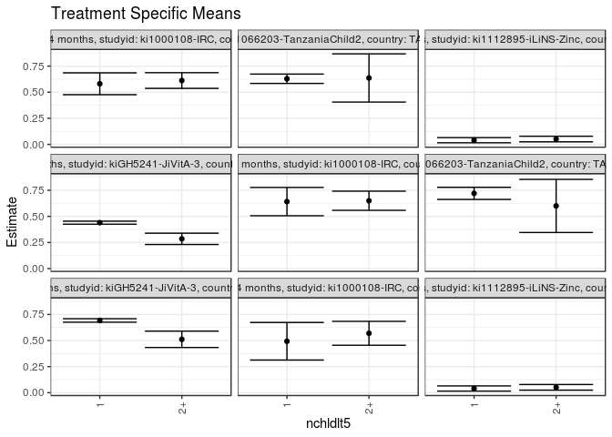

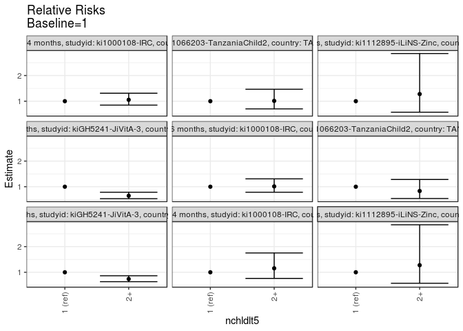

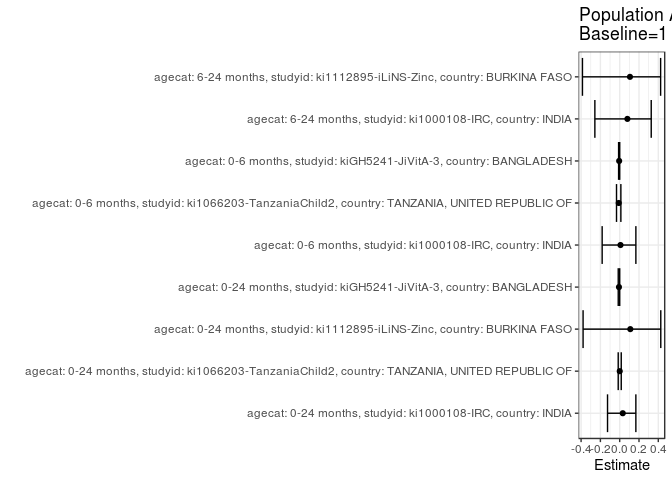

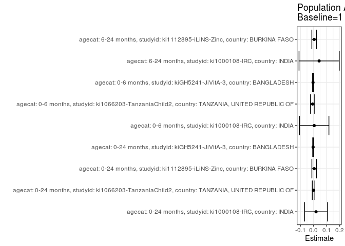

## Results Table

### Parameter: TSM

| agecat | studyid | country | intervention_level | baseline_level | estimate | ci_lower | ci_upper |
| --- | --- | --- | --- | --- | --- | --- | --- |
| 0-24 months | ki1000108-IRC | INDIA | 1 | NA | 0.5808905 | 0.4762064 | 0.6855746 |
| 0-24 months | ki1000108-IRC | INDIA | 2+ | NA | 0.6118300 | 0.5367436 | 0.6869165 |
| 0-24 months | ki1066203-TanzaniaChild2 | TANZANIA, UNITED REPUBLIC OF | 1 | NA | 0.6287425 | 0.5840238 | 0.6734612 |
| 0-24 months | ki1066203-TanzaniaChild2 | TANZANIA, UNITED REPUBLIC OF | 2+ | NA | 0.6363636 | 0.4056097 | 0.8671176 |
| 0-24 months | ki1112895-iLiNS-Zinc | BURKINA FASO | 1 | NA | 0.0402885 | 0.0156463 | 0.0649306 |
| 0-24 months | ki1112895-iLiNS-Zinc | BURKINA FASO | 2+ | NA | 0.0514641 | 0.0245461 | 0.0783821 |
| 0-24 months | kiGH5241-JiVitA-3 | BANGLADESH | 1 | NA | 0.4396904 | 0.4254031 | 0.4539776 |
| 0-24 months | kiGH5241-JiVitA-3 | BANGLADESH | 2+ | NA | 0.2847950 | 0.2306727 | 0.3389173 |
| 0-6 months | ki1000108-IRC | INDIA | 1 | NA | 0.6417263 | 0.5062376 | 0.7772149 |
| 0-6 months | ki1000108-IRC | INDIA | 2+ | NA | 0.6497771 | 0.5578427 | 0.7417115 |
| 0-6 months | ki1066203-TanzaniaChild2 | TANZANIA, UNITED REPUBLIC OF | 1 | NA | 0.7203390 | 0.6621405 | 0.7785374 |
| 0-6 months | ki1066203-TanzaniaChild2 | TANZANIA, UNITED REPUBLIC OF | 2+ | NA | 0.6000000 | 0.3454906 | 0.8545094 |
| 0-6 months | kiGH5241-JiVitA-3 | BANGLADESH | 1 | NA | 0.6923691 | 0.6757611 | 0.7089771 |
| 0-6 months | kiGH5241-JiVitA-3 | BANGLADESH | 2+ | NA | 0.5116241 | 0.4331622 | 0.5900859 |
| 6-24 months | ki1000108-IRC | INDIA | 1 | NA | 0.4931289 | 0.3132112 | 0.6730466 |
| 6-24 months | ki1000108-IRC | INDIA | 2+ | NA | 0.5693310 | 0.4546161 | 0.6840458 |
| 6-24 months | ki1112895-iLiNS-Zinc | BURKINA FASO | 1 | NA | 0.0404426 | 0.0156942 | 0.0651910 |
| 6-24 months | ki1112895-iLiNS-Zinc | BURKINA FASO | 2+ | NA | 0.0516112 | 0.0247863 | 0.0784360 |

### Parameter: E(Y)

| agecat | studyid | country | intervention_level | baseline_level | estimate | ci_lower | ci_upper |
| --- | --- | --- | --- | --- | --- | --- | --- |
| 0-24 months | ki1000108-IRC | INDIA | NA | NA | 0.6000000 | 0.5401100 | 0.6598900 |
| 0-24 months | ki1066203-TanzaniaChild2 | TANZANIA, UNITED REPUBLIC OF | NA | NA | 0.6290631 | 0.5851444 | 0.6729818 |
| 0-24 months | ki1112895-iLiNS-Zinc | BURKINA FASO | NA | NA | 0.0452675 | 0.0270667 | 0.0634683 |
| 0-24 months | kiGH5241-JiVitA-3 | BANGLADESH | NA | NA | 0.4364390 | 0.4227700 | 0.4501080 |
| 0-6 months | ki1000108-IRC | INDIA | NA | NA | 0.6470588 | 0.5734270 | 0.7206907 |
| 0-6 months | ki1066203-TanzaniaChild2 | TANZANIA, UNITED REPUBLIC OF | NA | NA | 0.7131474 | 0.6562470 | 0.7700478 |
| 0-6 months | kiGH5241-JiVitA-3 | BANGLADESH | NA | NA | 0.6885705 | 0.6725523 | 0.7045888 |
| 6-24 months | ki1000108-IRC | INDIA | NA | NA | 0.5360000 | 0.4424375 | 0.6295625 |
| 6-24 months | ki1112895-iLiNS-Zinc | BURKINA FASO | NA | NA | 0.0452675 | 0.0270667 | 0.0634683 |

### Parameter: RR

| agecat | studyid | country | intervention_level | baseline_level | estimate | ci_lower | ci_upper |
| --- | --- | --- | --- | --- | --- | --- | --- |
| 0-24 months | ki1000108-IRC | INDIA | 1 | 1 | 1.0000000 | 1.0000000 | 1.0000000 |
| 0-24 months | ki1000108-IRC | INDIA | 2+ | 1 | 1.0532622 | 0.8467197 | 1.3101871 |
| 0-24 months | ki1066203-TanzaniaChild2 | TANZANIA, UNITED REPUBLIC OF | 1 | 1 | 1.0000000 | 1.0000000 | 1.0000000 |
| 0-24 months | ki1066203-TanzaniaChild2 | TANZANIA, UNITED REPUBLIC OF | 2+ | 1 | 1.0121212 | 0.6994313 | 1.4646033 |
| 0-24 months | ki1112895-iLiNS-Zinc | BURKINA FASO | 1 | 1 | 1.0000000 | 1.0000000 | 1.0000000 |
| 0-24 months | ki1112895-iLiNS-Zinc | BURKINA FASO | 2+ | 1 | 1.2773908 | 0.5708790 | 2.8582715 |
| 0-24 months | kiGH5241-JiVitA-3 | BANGLADESH | 1 | 1 | 1.0000000 | 1.0000000 | 1.0000000 |
| 0-24 months | kiGH5241-JiVitA-3 | BANGLADESH | 2+ | 1 | 0.6477172 | 0.5342324 | 0.7853093 |
| 0-6 months | ki1000108-IRC | INDIA | 1 | 1 | 1.0000000 | 1.0000000 | 1.0000000 |
| 0-6 months | ki1000108-IRC | INDIA | 2+ | 1 | 1.0125456 | 0.7847859 | 1.3064054 |
| 0-6 months | ki1066203-TanzaniaChild2 | TANZANIA, UNITED REPUBLIC OF | 1 | 1 | 1.0000000 | 1.0000000 | 1.0000000 |
| 0-6 months | ki1066203-TanzaniaChild2 | TANZANIA, UNITED REPUBLIC OF | 2+ | 1 | 0.8329412 | 0.5408570 | 1.2827623 |
| 0-6 months | kiGH5241-JiVitA-3 | BANGLADESH | 1 | 1 | 1.0000000 | 1.0000000 | 1.0000000 |
| 0-6 months | kiGH5241-JiVitA-3 | BANGLADESH | 2+ | 1 | 0.7389470 | 0.6327255 | 0.8630008 |
| 6-24 months | ki1000108-IRC | INDIA | 1 | 1 | 1.0000000 | 1.0000000 | 1.0000000 |
| 6-24 months | ki1000108-IRC | INDIA | 2+ | 1 | 1.1545277 | 0.7603564 | 1.7530385 |
| 6-24 months | ki1112895-iLiNS-Zinc | BURKINA FASO | 1 | 1 | 1.0000000 | 1.0000000 | 1.0000000 |
| 6-24 months | ki1112895-iLiNS-Zinc | BURKINA FASO | 2+ | 1 | 1.2761566 | 0.5711318 | 2.8514884 |

### Parameter: PAR

| agecat | studyid | country | intervention_level | baseline_level | estimate | ci_lower | ci_upper |
| --- | --- | --- | --- | --- | --- | --- | --- |
| 0-24 months | ki1000108-IRC | INDIA | 1 | NA | 0.0191095 | -0.0686481 | 0.1068670 |
| 0-24 months | ki1066203-TanzaniaChild2 | TANZANIA, UNITED REPUBLIC OF | 1 | NA | 0.0003206 | -0.0095522 | 0.0101934 |
| 0-24 months | ki1112895-iLiNS-Zinc | BURKINA FASO | 1 | NA | 0.0049790 | -0.0126702 | 0.0226283 |
| 0-24 months | kiGH5241-JiVitA-3 | BANGLADESH | 1 | NA | -0.0032514 | -0.0065654 | 0.0000627 |
| 0-6 months | ki1000108-IRC | INDIA | 1 | NA | 0.0053325 | -0.1070980 | 0.1177631 |
| 0-6 months | ki1066203-TanzaniaChild2 | TANZANIA, UNITED REPUBLIC OF | 1 | NA | -0.0071916 | -0.0232105 | 0.0088274 |
| 0-6 months | kiGH5241-JiVitA-3 | BANGLADESH | 1 | NA | -0.0037985 | -0.0077238 | 0.0001267 |
| 6-24 months | ki1000108-IRC | INDIA | 1 | NA | 0.0428711 | -0.1109618 | 0.1967040 |
| 6-24 months | ki1112895-iLiNS-Zinc | BURKINA FASO | 1 | NA | 0.0048248 | -0.0129272 | 0.0225769 |

### Parameter: PAF

| agecat | studyid | country | intervention_level | baseline_level | estimate | ci_lower | ci_upper |
| --- | --- | --- | --- | --- | --- | --- | --- |
| 0-24 months | ki1000108-IRC | INDIA | 1 | NA | 0.0318491 | -0.1259640 | 0.1675435 |
| 0-24 months | ki1066203-TanzaniaChild2 | TANZANIA, UNITED REPUBLIC OF | 1 | NA | 0.0005096 | -0.0153076 | 0.0160805 |
| 0-24 months | ki1112895-iLiNS-Zinc | BURKINA FASO | 1 | NA | 0.1099915 | -0.3793584 | 0.4257365 |
| 0-24 months | kiGH5241-JiVitA-3 | BANGLADESH | 1 | NA | -0.0074497 | -0.0150591 | 0.0001026 |
| 0-6 months | ki1000108-IRC | INDIA | 1 | NA | 0.0082412 | -0.1816883 | 0.1676438 |
| 0-6 months | ki1066203-TanzaniaChild2 | TANZANIA, UNITED REPUBLIC OF | 1 | NA | -0.0100843 | -0.0328613 | 0.0121904 |
| 0-6 months | kiGH5241-JiVitA-3 | BANGLADESH | 1 | NA | -0.0055166 | -0.0112309 | 0.0001655 |
| 6-24 months | ki1000108-IRC | INDIA | 1 | NA | 0.0799834 | -0.2572574 | 0.3267643 |
| 6-24 months | ki1112895-iLiNS-Zinc | BURKINA FASO | 1 | NA | 0.1065851 | -0.3858903 | 0.4240597 |